**Einführung in PyTorch**

Dr. Matthias Hölzl

# Introduction to PyTorch

PyTorch is an open-source machine learning library developed by Facebook's AI Research lab. It provides:

- **Tensors**: Similar to NumPy arrays, but with support for GPU acceleration.
- **Dynamic Computation Graphs**: Allows flexibility in building and modifying neural networks during runtime.
- **Autograd Module**: Automatic differentiation for Tensors.

In this notebook, we will explore PyTorch functionalities and learn how to build neural networks using PyTorch.

```python
import matplotlib.pyplot as plt
import numpy as np
import torch
import torch.nn as nn

from torch.utils.data import TensorDataset, DataLoader
from sklearn.datasets import fetch_openml
from sklearn.model_selection import train_test_split
from sklearn.metrics import (
    accuracy_score,
    balanced_accuracy_score,
    f1_score,
    precision_score,
    recall_score,
)
from skorch import NeuralNetClassifier
```

## PyTorch Basics

### Tensors

Tensors are the fundamental data structure in PyTorch. They are similar to NumPy arrays but can be used for GPU acceleration.

- Parameters: `data`, `dtype`, `device`, `requires_grad`.
- `data` can be a list, tuple, NumPy array, scalar, etc.
- `dtype` specifies the data type of the tensor.
- `device` specifies the device (CPU or GPU) where the tensor will be stored.
- `requires_grad` specifies whether the tensor requires gradient computation.

```python
a = torch.tensor([1, 2, 3])
```

```python
a
```

```
tensor([1, 2, 3])
```

```python
type(a)
```

```
torch.Tensor
```

```python
b = torch.tensor([4, 5, 6])
```

```python
b
```

```
tensor([4, 5, 6])
```

```python
a + b
```

```
tensor([5, 7, 9])
```

```python
a * b
```

```
tensor([ 4, 10, 18])
```

#### Example for Gradient Computation

```python
x = torch.tensor([1.0, 2.0, 3.0], requires_grad=True)
```

```python
x
```

```
tensor([1., 2., 3.], requires_grad=True)
```

```python
y = x**2
```

```python
z = y.sum()
```

```python
z.backward()
```

```python
x.grad
```

```
tensor([2., 4., 6.])
```

```python
mat = np.linspace(1.0, 6.0, 6).reshape(2, 3)
```

```python
x = torch.tensor(mat, requires_grad=True)
```

```python
x
```

```
tensor([[1., 2., 3.],
        [4., 5., 6.]], dtype=torch.float64, requires_grad=True)
```

```python
y = 2 * x**3
```

```python
z = y.sum()
```

```python
z.backward()
```

```python
x.grad
```

```
tensor([[  6.,  24.,  54.],
        [ 96., 150., 216.]], dtype=torch.float64)
```

```python
2 * 3 * mat**2
```

```
array([[  6.,  24.,  54.],
       [ 96., 150., 216.]])
```

### Converting between NumPy arrays and PyTorch tensors

```python
a_np = a.numpy()
```

```python
a_np
```

```
array([1, 2, 3])
```

```python
type(a_np)
```

```
numpy.ndarray
```

```python
np_array = np.array([7, 8, 9])
```

```python
tensor_from_np = torch.from_numpy(np_array)
```

```python
tensor_from_np
```

```
tensor([7, 8, 9])
```

```python
type(tensor_from_np)
```

```
torch.Tensor
```

## PyTorch Functions and Modules

Let's explore some PyTorch functions used in building neural networks.

### `torch.randn`

**Description**:

- Returns a tensor filled with random numbers from a normal distribution.
- Parameters: `size`, `dtype`, `device`, `requires_grad`.
- `size` can be a single integer, a tuple of integers, or passed as several parameters.
- `dtype` specifies the data type of the output tensor.
- `device` specifies the device (CPU or GPU) where the tensor will be stored.
- `requires_grad` specifies whether the tensor requires gradient computation.
  - Gradients are used for backpropagation in neural networks.
  - If `requires_grad=True`, PyTorch will track operations on the tensor.
  - The gradient can be accessed using the `.grad` attribute.

```python
torch.randn(2, 3)
```

```
tensor([[ 1.9804,  0.5730, -1.2849],
        [-1.2115,  0.1180, -0.8319]])
```

```python
torch.randn((2, 3))
```

```
tensor([[ 0.0546, -0.8868,  1.4437],
        [-0.4070, -1.3020,  2.7390]])
```

```python
torch.randn(2, 3, dtype=torch.float16)
```

```
tensor([[-0.2255, -1.1670, -0.5518],
        [-0.2927, -0.6235,  1.0527]], dtype=torch.float16)
```

```python
device = torch.device("cuda" if torch.cuda.is_available() else "cpu")
```

```python
torch.randn(2, 3, device=device)
```

```
tensor([[ 0.1147,  1.5077, -0.6875],
        [-0.5915, -0.0967, -0.0948]])
```

```python
torch.randn(2, 3, requires_grad=True)
```

```
tensor([[ 1.7832, -2.4052,  0.1921],
        [ 0.7662,  0.3574, -1.5951]], requires_grad=True)
```

### torch.view()

**Description**:

- Returns a new tensor with the same data but a different shape.
- The returned tensor shares the same data with the original tensor.

```python
x = torch.randn(2, 3, 4)
```

```python
x.shape
```

```
torch.Size([2, 3, 4])
```

```python
x_view = x.view(-1, 4)  # Flatten the first two dimensions
```

```python
x_view.shape
```

```
torch.Size([6, 4])
```

### torch.max

**Description**:

- Returns the maximum value of all elements in the input tensor.

```python
x = torch.tensor([1.0, 3.0, 2.0, 5.0])
```

```python
torch.max(x)
```

```
tensor(5.)
```

```python
x = torch.tensor([[1, 2], [3, 4], [4, 2]])
```

```python
max_values, indices = torch.max(x, dim=0)
print("Max values along dim=1:", max_values)
print("Indices:", indices)
```

```
Max values along dim=1: tensor([4, 4])
Indices: tensor([2, 1])
```

```python
max_values, indices = torch.max(x, dim=1)
print("Max values along dim=1:", max_values)
print("Indices:", indices)
```

```
Max values along dim=1: tensor([2, 4, 4])
Indices: tensor([1, 1, 0])
```

```python
torch.max(torch.linspace(-3, 3, steps=7), torch.zeros(7))
```

```
tensor([0., 0., 0., 0., 1., 2., 3.])
```

### torch.nn.Module

**Description**:

- Base class for all neural network modules.
- Your models should subclass `nn.Module`.
- Modules can contain other modules, allowing for nested structures.

```python
class SimpleNet(nn.Module):
    def __init__(self):
        super().__init__()
        self.W1 = nn.Parameter(torch.randn(2, 3) * 0.01)
        self.b1 = nn.Parameter(torch.zeros(3))
        self.W2 = nn.Parameter(torch.randn(3, 1) * 0.01)
        self.b2 = nn.Parameter(torch.zeros(1))

    def forward(self, x):
        z1 = x @ self.W1 + self.b1
        a1 = torch.max(z1, torch.zeros_like(z1))
        z2 = a1 @ self.W2 + self.b2
        return z2  # Outputs logits
```

```python
simple_net = SimpleNet()
```

```python
simple_net
```

```
SimpleNet()
```

```python
simple_net.forward(torch.ones(2))
```

```
tensor([0.], grad_fn=<AddBackward0>)
```

```python
simple_net(torch.ones(2))
```

```
tensor([0.], grad_fn=<AddBackward0>)
```

```python
simple_net.zero_grad()
```

```python
def generate_training_data(max=5, shuffle=True):
    values = torch.cat(
        [torch.tensor([[n, n + 2]], dtype=torch.float32) for n in range(-max, max + 1)],
        dim=0,
    )
    n_samples = values.shape[0]
    shuffle_indices = torch.randperm(n_samples) if shuffle else torch.arange(n_samples)
    return values[shuffle_indices]
```

```python
generate_training_data(3, shuffle=False)
```

```
tensor([[-3., -1.],
        [-2.,  0.],
        [-1.,  1.],
        [ 0.,  2.],
        [ 1.,  3.],
        [ 2.,  4.],
        [ 3.,  5.]])
```

```python
training_data = generate_training_data()
```

```python
training_data
```

```
tensor([[-1.,  1.],
        [-3., -1.],
        [ 1.,  3.],
        [-4., -2.],
        [ 4.,  6.],
        [-5., -3.],
        [ 0.,  2.],
        [ 2.,  4.],
        [-2.,  0.],
        [ 3.,  5.],
        [ 5.,  7.]])
```

```python
def results_from_training_data(training_data):
    return 0.01 * (training_data[:, 0].reshape(-1, 1) + 1)
```

```python
expected_output = results_from_training_data(training_data)
```

```python
expected_output
```

```
tensor([[ 0.0000],
        [-0.0200],
        [ 0.0200],
        [-0.0300],
        [ 0.0500],
        [-0.0400],
        [ 0.0100],
        [ 0.0300],
        [-0.0100],
        [ 0.0400],
        [ 0.0600]])
```

```python
result = simple_net(training_data)
```

```python
result
```

```
tensor([[ 7.3240e-05],
        [ 7.7778e-04],
        [-1.9125e-04],
        [ 1.2263e-03],
        [-1.6400e-04],
        [ 1.6747e-03],
        [-1.5481e-04],
        [-1.8217e-04],
        [ 3.2930e-04],
        [-1.7308e-04],
        [-1.5491e-04]], grad_fn=<AddBackward0>)
```

```python
loss = (result - expected_output).abs().mean()
```

```python
loss
```

```
tensor(0.0286, grad_fn=<MeanBackward0>)
```

```python
loss.backward()
```

```python
simple_net.W1.grad
```

```
tensor([[-0.0207, -0.0222,  0.0430],
        [-0.0089, -0.0103,  0.0459]])
```

```python
simple_net.b1.grad
```

```
tensor([0.0059, 0.0059, 0.0014])
```

```python
eval_data = generate_training_data(5, shuffle=False)
results_from_training_data(eval_data)
```

```
tensor([[-0.0400],
        [-0.0300],
        [-0.0200],
        [-0.0100],
        [ 0.0000],
        [ 0.0100],
        [ 0.0200],
        [ 0.0300],
        [ 0.0400],
        [ 0.0500],
        [ 0.0600]])
```

```python
# Update the parameters
with torch.no_grad():
    for param in simple_net.parameters():
        param -= 0.1 * param.grad
    print(simple_net(eval_data))
```

```
tensor([[0.0096],
        [0.0094],
        [0.0092],
        [0.0091],
        [0.0091],
        [0.0091],
        [0.0091],
        [0.0091],
        [0.0091],
        [0.0091],
        [0.0091]])
```

```python
def loss():
    return (simple_net(eval_data) - expected_output).abs().mean().item()
```

```python
loss()
```

```
0.027418790385127068
```

```python
def run_training_loop(model, num_epochs=100, num_samples=2000, learning_rate=1e-4):
    training_data = generate_training_data(num_samples)
    expected_output = results_from_training_data(training_data)
    for epoch in range(num_epochs):
        result = model(training_data)
        loss = (result - expected_output).abs().mean()
        loss.backward()
        with torch.no_grad():
            for param in model.parameters():
                param -= learning_rate * param.grad
        model.zero_grad()
        if epoch % (num_epochs / 10) == 0:
            print(f"Epoch {epoch}, loss: {loss.item():.5f}")
```

```python
def print_results():
    eval_data = generate_training_data(5, shuffle=False)
    expected = results_from_training_data(eval_data).detach().numpy()
    predicted = simple_net(eval_data).detach().numpy()
    error = np.abs(predicted - expected)
    values = (
        np.concatenate(
            [
                expected,
                predicted,
                error,
            ],
            axis=1,
        )
        * 10_000
    )
    np.set_printoptions(precision=2)
    print("Expected | Predicted | Error")
    print(values)
```

```python
print_results()
```

```
Expected | Predicted | Error
[[-400.     95.96  495.96]
 [-300.     94.22  394.22]
 [-200.     92.47  292.47]
 [-100.     91.2   191.2 ]
 [   0.     91.09   91.09]
 [ 100.     90.98    9.02]
 [ 200.     90.91  109.09]
 [ 300.     90.91  209.09]
 [ 400.     90.91  309.09]
 [ 500.     90.91  409.09]
 [ 600.     90.91  509.09]]
```

```python
torch.random.manual_seed(42)
simple_net = SimpleNet()
```

```python
print_results()
```

```
Expected | Predicted | Error
[[-4.00e+02 -1.74e+00  3.98e+02]
 [-3.00e+02 -1.10e+00  2.99e+02]
 [-2.00e+02 -4.70e-01  2.00e+02]
 [-1.00e+02  0.00e+00  1.00e+02]
 [ 0.00e+00  0.00e+00  0.00e+00]
 [ 1.00e+02  1.02e+00  9.90e+01]
 [ 2.00e+02  2.27e+00  1.98e+02]
 [ 3.00e+02  3.52e+00  2.96e+02]
 [ 4.00e+02  4.77e+00  3.95e+02]
 [ 5.00e+02  6.03e+00  4.94e+02]
 [ 6.00e+02  7.28e+00  5.93e+02]]
```

```python
run_training_loop(simple_net)
```

```
Epoch 0, loss: 9.90708
Epoch 10, loss: 9.40200
Epoch 20, loss: 7.59302
Epoch 30, loss: 3.77839
Epoch 40, loss: 1.04267
Epoch 50, loss: 0.50243
Epoch 60, loss: 0.20465
Epoch 70, loss: 0.50003
Epoch 80, loss: 0.96481
Epoch 90, loss: 1.20232
```

```python
print_results()
```

```
Expected | Predicted | Error
[[-4.00e+02 -4.37e+02  3.70e+01]
 [-3.00e+02 -3.26e+02  2.63e+01]
 [-2.00e+02 -2.16e+02  1.55e+01]
 [-1.00e+02 -1.05e+02  4.79e+00]
 [ 0.00e+00 -4.96e+00  4.96e+00]
 [ 1.00e+02  9.99e+01  1.22e-01]
 [ 2.00e+02  2.06e+02  6.17e+00]
 [ 3.00e+02  3.12e+02  1.25e+01]
 [ 4.00e+02  4.19e+02  1.88e+01]
 [ 5.00e+02  5.25e+02  2.50e+01]
 [ 6.00e+02  6.31e+02  3.13e+01]]
```

```python
torch.random.manual_seed(42)
simple_net = SimpleNet()
run_training_loop(simple_net, num_epochs=60)
```

```
Epoch 0, loss: 9.90708
Epoch 6, loss: 9.67219
Epoch 12, loss: 9.20508
Epoch 18, loss: 8.17148
Epoch 24, loss: 5.83484
Epoch 30, loss: 3.77839
Epoch 36, loss: 1.18919
Epoch 42, loss: 0.93244
Epoch 48, loss: 0.60832
Epoch 54, loss: 0.29382
```

```python
print_results()
```

```
Expected | Predicted | Error
[[-4.00e+02 -4.02e+02  2.25e+00]
 [-3.00e+02 -3.00e+02  3.08e-01]
 [-2.00e+02 -1.98e+02  1.63e+00]
 [-1.00e+02 -9.64e+01  3.57e+00]
 [ 0.00e+00 -4.97e+00  4.97e+00]
 [ 1.00e+02  9.15e+01  8.53e+00]
 [ 2.00e+02  1.89e+02  1.07e+01]
 [ 3.00e+02  2.87e+02  1.28e+01]
 [ 4.00e+02  3.85e+02  1.50e+01]
 [ 5.00e+02  4.83e+02  1.71e+01]
 [ 6.00e+02  5.81e+02  1.93e+01]]
```

```python
run_training_loop(simple_net, num_epochs=100, learning_rate=1e-5)
```

```
Epoch 0, loss: 0.20465
Epoch 10, loss: 0.07799
```

```
Epoch 20, loss: 0.07792
Epoch 30, loss: 0.07786
Epoch 40, loss: 0.07779
```

```
Epoch 50, loss: 0.07770
Epoch 60, loss: 0.07760
Epoch 70, loss: 0.07746
Epoch 80, loss: 0.07722
```

```
Epoch 90, loss: 0.07676
```

```python
print_results()
```

```
Expected | Predicted | Error
[[-400.   -389.11   10.89]
 [-300.   -290.45    9.55]
 [-200.   -191.8     8.2 ]
 [-100.    -93.14    6.86]
 [   0.     -4.8     4.8 ]
 [ 100.     93.95    6.05]
 [ 200.    194.12    5.88]
 [ 300.    294.29    5.71]
 [ 400.    394.46    5.54]
 [ 500.    494.63    5.37]
 [ 600.    594.8     5.2 ]]
```

```python
run_training_loop(simple_net, num_epochs=1000, learning_rate=1e-6)
```

```
Epoch 0, loss: 0.07567
```

```
Epoch 100, loss: 0.00724
```

```
Epoch 200, loss: 0.00701
```

```
Epoch 300, loss: 0.00689
```

```
Epoch 400, loss: 0.00680
```

```
Epoch 500, loss: 0.00675
```

```
Epoch 600, loss: 0.00671
```

```
Epoch 700, loss: 0.00667
```

```
Epoch 800, loss: 0.00663
```

```
Epoch 900, loss: 0.00659
```

```python
print_results()
```

```
Expected | Predicted | Error
[[-400.   -394.94    5.06]
 [-300.   -294.82    5.18]
 [-200.   -194.7     5.3 ]
 [-100.    -94.58    5.42]
 [   0.     -4.84    4.84]
 [ 100.     93.74    6.26]
 [ 200.    193.73    6.27]
 [ 300.    293.72    6.28]
 [ 400.    393.71    6.29]
 [ 500.    493.7     6.3 ]
 [ 600.    593.7     6.3 ]]
```

### `torch.nn.Flatten` and `torch.flatten`

**Description**:

- Flattens a contiguous range of dimensions into a tensor.
- Commonly used to flatten inputs before feeding them into fully connected layers.
- `nn.Flatten` is a module, while `torch.flatten` is a functional interface.

```python
flatten = nn.Flatten()
```

```python
input_tensor = torch.randn(1, 2, 3)
```

```python
input_tensor.shape
```

```
torch.Size([1, 2, 3])
```

```python
flattened_tensor = flatten(input_tensor)
```

```python
flattened_tensor.shape
```

```
torch.Size([1, 6])
```

### torch.nn.Linear

**Description**:

- Applies a linear transformation to the incoming data: $y = xA^T + b$
- Parameters: `in_features`, `out_features`

```python
linear_layer = nn.Linear(3, 2)
input_tensor = torch.randn(1, 3)
output_tensor = linear_layer(input_tensor)
```

```python
input_tensor
```

```
tensor([[-0.5012,  1.2004,  0.2400]])
```

```python
output_tensor
```

```
tensor([[-0.1203,  0.8764]], grad_fn=<AddmmBackward0>)
```

```python
linear_layer.weight
```

```
Parameter containing:
tensor([[ 0.4763, -0.1780, -0.5654],
        [-0.1939,  0.3919,  0.1662]], requires_grad=True)
```

```python
linear_layer.bias
```

```
Parameter containing:
tensor([0.4678, 0.2689], requires_grad=True)
```

```python
input_tensor @ linear_layer.weight.T + linear_layer.bias
```

```
tensor([[-0.1203,  0.8764]], grad_fn=<AddBackward0>)
```

```python
output_tensor
```

```
tensor([[-0.1203,  0.8764]], grad_fn=<AddmmBackward0>)
```

### torch.nn.ReLU and torch.relu

**Description**:

- The ReLU activation function introduces non-linearity.
- `nn.ReLU` is a module, while `torch.relu` is a functional interface.

```python
x = torch.tensor([-2.0, -1.0, 0.0, 1.0, 2.0])
```

```python
x
```

```
tensor([-2., -1.,  0.,  1.,  2.])
```

```python
torch.relu(x)
```

```
tensor([0., 0., 0., 1., 2.])
```

**Visualization**:

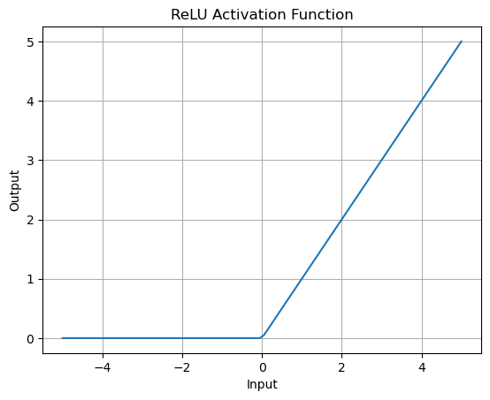

```python
relu_module = nn.ReLU()
x = torch.linspace(-5, 5, steps=100)
y = relu_module(x)
plt.plot(x.numpy(), y.numpy())
plt.title("ReLU Activation Function")
plt.xlabel("Input")
plt.ylabel("Output")
plt.grid(True)
plt.show()
```

### torch.nn.Softmax and torch.softmax

**Description**:

- Applies the Softmax function to a tensor.
- Converts logits into probabilities that sum to 1.

**Visualization**:

```python
softmax_module = nn.Softmax(dim=0)
logits = torch.tensor([1.0, 2.0, 3.0])
probabilities = softmax_module(logits)
print("Logits:", logits)
print("Probabilities after Softmax:", probabilities)
print("Sum of probabilities:", probabilities.sum())
```

```
Logits: tensor([1., 2., 3.])
Probabilities after Softmax: tensor([0.0900, 0.2447, 0.6652])
Sum of probabilities: tensor(1.)
```

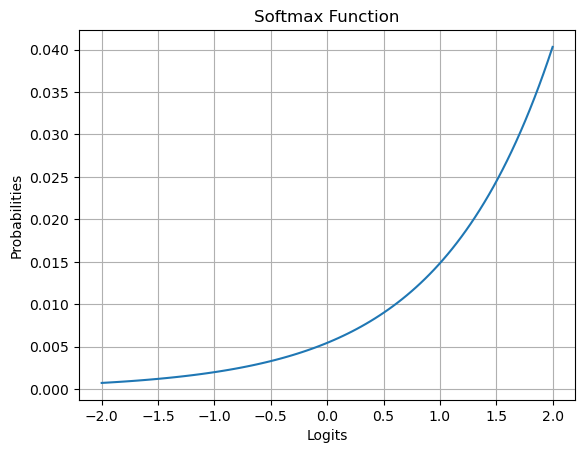

```python
logits = torch.linspace(-2, 2, steps=100)
probabilities = torch.softmax(logits, dim=0)
plt.plot(logits.numpy(), probabilities.numpy())
plt.title("Softmax Function")
plt.xlabel("Logits")
plt.ylabel("Probabilities")
plt.grid(True)
plt.show()
```

### torch.nn.Conv2d

**Description**:

- Applies a 2D convolution over an input signal composed of several input planes.

```python
# Example of a Conv2d layer
conv_layer = nn.Conv2d(in_channels=1, out_channels=1, kernel_size=3)
input_image = torch.randn(1, 1, 5, 5)  # Batch size, channels, height, width
output_image = conv_layer(input_image)
print("Input shape:", input_image.shape)
print("Output shape:", output_image.shape)
```

```
Input shape: torch.Size([1, 1, 5, 5])
Output shape: torch.Size([1, 1, 3, 3])
```